# Barbell Lifts: Did I Do It Right?

Shelley Stall

Saturday, May 23, 2015

## Project Goal

Determine if the subject performaing a “barbell lift” used the correct form (Classe “A”). If they didn’t, which of the four (4) form errors did they make (Classe “B” through “E”).

## Background

We commonly use personal activity monitors to track our level of activity to help us reach health and fitness goals. It’s more of a challenge to determine if a particular activity is being done correctly. In this project, we use data from accelerometers on the belt, forearm, arm, and dumbbell (or barbell) of 6 participants. They were asked to perform barbell lifts correctly and incorrectly totally 5 different ways.

| Prediction Classes | Description |
| --- | --- |
| Class A | Barbell lift exactly according to specfications |
| Class B | Throwing the Elbows to the front |
| Class C | Lifting the dumbbell only halfway |
| Class D | Lowering the dumbbell only halfway |
| Class E | Throwing the hips to the front |

More information is available from the website here: http://groupware.les.inf.puc-rio.br/har (see the section on the Weight Lifting Exercise Dataset).

## How the Model was Built

The data was downloaded and exploration was done to determine if any tidying was needed. There were missing values and division by zero error codes that needed to be managed. For the model, random forest using the caret package was selected. Random forest is very accurate, but with the caret packet could be very slow.

The classe data is converted to a factor element. Columns with complete data are determined and kept. Columns that won’t contribute to the prediction such as row numbers, subject name, time stamps, and time window ids are removed.

```r
require(ggplot2)
require(caret)
set.seed(31456)
mysandbox <- read.csv("pml-training.csv", na.strings=c("NA", "#DIV/0!"), stringsAsFactors = FALSE)
## Convert classe to a factor
mysandbox$classe <- as.factor(mysandbox$classe)
## Identify columns with all missing data
mysandbox_NA <- mysandbox[,colSums(is.na(mysandbox)) == 0]
## Select the colunms that will support prediction
tidy_sandbox <- mysandbox_NA[,8:60]
## Prepare a training (60%) and testing (40%) set.
inTrain <- createDataPartition(y=tidy_sandbox$classe, p=0.6, list=FALSE)
training <- tidy_sandbox[inTrain,]
testing <- tidy_sandbox[-inTrain,]
```

### Data

The training and testing dataset for the project is a subset of the Weight LIfting Exercise Dataset noted above.

To give you a sense for how two important data elements work together in the data, plotted below is pitch_forearm and roll_forarm from the training dataset, colored by the class. Remember, class A is being done in correct form.

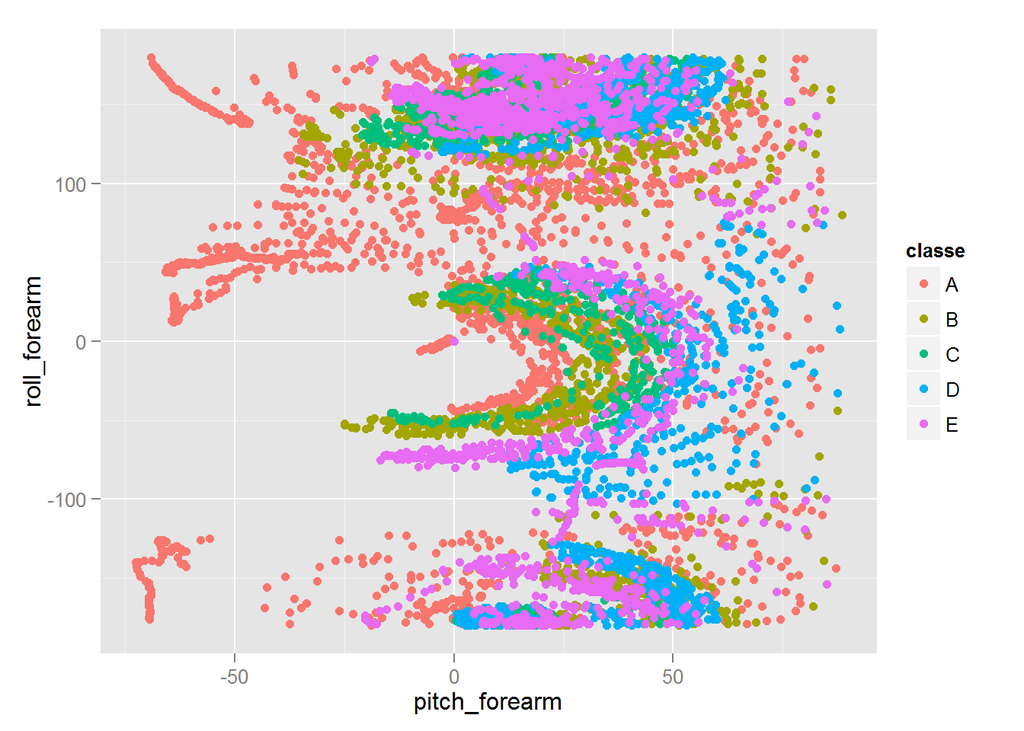

### The Model

```r
rfmodFit <- train(classe ~.,data=training,method="rf",prox=TRUE)
```

### Cross Validation

When preparing the training and testing set of the provided data, a **random sampling** of training data (60%) was selected from the provided training data for the class. By randomly dividing the data into to sets we can perform cross validation and determine the probable accuracy of our model before using the actual testing data.

```r
rfmodFit
```

```
## Random Forest
##
## 11776 samples
##    52 predictor
##     5 classes: 'A', 'B', 'C', 'D', 'E'
##
## No pre-processing
## Resampling: Bootstrapped (25 reps)
##
## Summary of sample sizes: 11776, 11776, 11776, 11776, 11776, 11776, ...
##
## Resampling results across tuning parameters:
##
##   mtry  Accuracy   Kappa      Accuracy SD  Kappa SD
##    2    0.9861437  0.9824704  0.002553872  0.003233012
##   27    0.9866376  0.9830955  0.002150670  0.002724140
##   52    0.9800407  0.9747528  0.003947256  0.004988126
##
## Accuracy was used to select the optimal model using  the largest value.
## The final value used for the model was mtry = 27.
```

The list of variables in order of importance:

```r
varImp(rfmodFit)
```

```
## rf variable importance
##
##   only 20 most important variables shown (out of 52)
##
##                      Overall
## roll_belt             100.00
## pitch_forearm          60.17
## yaw_belt               52.56
## pitch_belt             45.29
## magnet_dumbbell_z      43.82
## magnet_dumbbell_y      42.37
## roll_forearm           40.65
## accel_dumbbell_y       20.71
## magnet_dumbbell_x      19.29
## accel_forearm_x        18.43
## roll_dumbbell          18.04
## magnet_belt_z          15.10
## accel_dumbbell_z       14.90
## accel_belt_z           13.00
## magnet_forearm_z       12.87
## total_accel_dumbbell   11.72
## yaw_arm                11.52
## magnet_belt_y          11.50
## magnet_belt_x          10.78
## gyros_belt_z           10.46
```

### Expected Out of Sample Error

Using our set aside testing model we predict the model performance.

```r
rfmodFit.predict = predict(rfmodFit,testing)
predMatrix = with(testing,table(rfmodFit.predict,classe))
sum(diag(predMatrix))/sum(as.vector(predMatrix))
```

```
## [1] 0.9915881
```

The accuracy is 99.15% This means that the expected out of sample error is .85% The full confusion matrix is below

```r
print(confusionMatrix(rfmodFit.predict, testing$classe), digits=4)
```

```
## Confusion Matrix and Statistics
##
##           Reference
## Prediction    A    B    C    D    E
##          A 2231   16    0    0    0
##          B    1 1499    7    0    1
##          C    0    2 1359   24    7
##          D    0    1    2 1262    5
##          E    0    0    0    0 1429
##
## Overall Statistics
##
##                Accuracy : 0.9916
##                  95% CI : (0.9893, 0.9935)
##     No Information Rate : 0.2845
##     P-Value [Acc > NIR] : < 2.2e-16
##
##                   Kappa : 0.9894
##  Mcnemar's Test P-Value : NA
##
## Statistics by Class:
##
##                      Class: A Class: B Class: C Class: D Class: E
## Sensitivity            0.9996   0.9875   0.9934   0.9813   0.9910
## Specificity            0.9971   0.9986   0.9949   0.9988   1.0000
## Pos Pred Value         0.9929   0.9940   0.9763   0.9937   1.0000
## Neg Pred Value         0.9998   0.9970   0.9986   0.9964   0.9980
## Prevalence             0.2845   0.1935   0.1744   0.1639   0.1838
## Detection Rate         0.2843   0.1911   0.1732   0.1608   0.1821
## Detection Prevalence   0.2864   0.1922   0.1774   0.1619   0.1821
## Balanced Accuracy      0.9984   0.9930   0.9942   0.9901   0.9955
```

## Comparision Model using RandomForest package

Using the randomforest function we define the number of trees limiting it to 100.

```r
require(randomForest)
randomforest_modFit=randomForest(classe ~.,data=training,ntree=100,importance=TRUE)
randomforest_modFit
```

```
##
## Call:
##  randomForest(formula = classe ~ ., data = training, ntree = 100,      importance = TRUE)
##                Type of random forest: classification
##                      Number of trees: 100
## No. of variables tried at each split: 7
##
##         OOB estimate of  error rate: 0.7%
## Confusion matrix:
##      A    B    C    D    E class.error
## A 3344    3    0    1    0 0.001194743
## B   22 2252    5    0    0 0.011847301
## C    0   14 2036    4    0 0.008763389
## D    1    0   22 1905    2 0.012953368
## E    0    0    1    7 2157 0.003695150
```

Plot of the important variable:

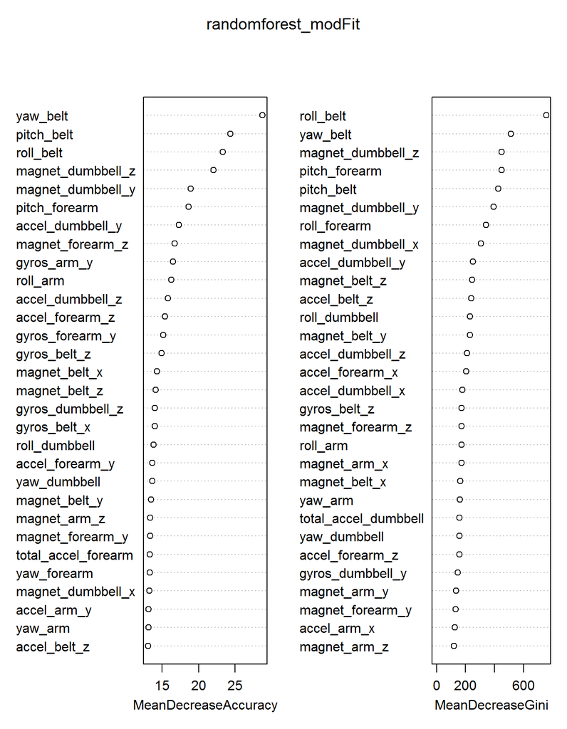

```r
varImpPlot(randomforest_modFit,)
```

### Expected Out of Sample Error

Using our randomly selected testing dataset we predict the model performance.

```r
ranfor_modFit.predict = predict(randomforest_modFit,testing)
pred002Matrix = with(testing,table(ranfor_modFit.predict,classe))
sum(diag(pred002Matrix))/sum(as.vector(pred002Matrix))
```

```
## [1] 0.9933724
```

The accuracy is 99.34% This means that the expected out of sample error is .66% The full confusion matrix is below:

```r
print(confusionMatrix(ranfor_modFit.predict, testing$classe), digits=4)
```

```
## Confusion Matrix and Statistics
##
##           Reference
## Prediction    A    B    C    D    E
##          A 2232    8    0    0    0
##          B    0 1508   11    0    0
##          C    0    2 1356   23    6
##          D    0    0    1 1263    1
##          E    0    0    0    0 1435
##
## Overall Statistics
##
##                Accuracy : 0.9934
##                  95% CI : (0.9913, 0.995)
##     No Information Rate : 0.2845
##     P-Value [Acc > NIR] : < 2.2e-16
##
##                   Kappa : 0.9916
##  Mcnemar's Test P-Value : NA
##
## Statistics by Class:
##
##                      Class: A Class: B Class: C Class: D Class: E
## Sensitivity            1.0000   0.9934   0.9912   0.9821   0.9951
## Specificity            0.9986   0.9983   0.9952   0.9997   1.0000
## Pos Pred Value         0.9964   0.9928   0.9776   0.9984   1.0000
## Neg Pred Value         1.0000   0.9984   0.9981   0.9965   0.9989
## Prevalence             0.2845   0.1935   0.1744   0.1639   0.1838
## Detection Rate         0.2845   0.1922   0.1728   0.1610   0.1829
## Detection Prevalence   0.2855   0.1936   0.1768   0.1612   0.1829
## Balanced Accuracy      0.9993   0.9958   0.9932   0.9909   0.9976
```

## Prepare the test submission

Read in the test data in the same manner as the training data:

```r
the_test_data <- read.csv("pml-testing.csv", na.strings=c("NA", "#DIV/0!"), stringsAsFactors = FALSE)
```

Results for the first model:

```r
the_test_data1.predict = predict(rfmodFit,the_test_data)
the_test_data1.predict
```

```
##  [1] B A B A A E D B A A B C B A E E A B B B
## Levels: A B C D E
```

Results for the second model:

```r
the_test_data2.predict = predict(randomforest_modFit,the_test_data)
the_test_data2.predict
```

```
##  1  2  3  4  5  6  7  8  9 10 11 12 13 14 15 16 17 18 19 20
##  B  A  B  A  A  E  D  B  A  A  B  C  B  A  E  E  A  B  B  B
## Levels: A B C D E
```

Identical results. Good.